# DEG analysis with EdgeR

Pablo L. Cardozo

2024-07-04

This document describes the main coding steps used in this work to remove batch effects using RUV-seq (residuals method), followed by EdgeR differential gene expression analysis.

### Loading required libraries and importing data files

```r
#Loading libraries
libs = c('dplyr', 'ggplot2', 'pheatmap', 'RUVSeq', 'sva', 'edgeR',
         'PCAtools',  'plotly', "tools", "jsonlite", "reshape2",
         "ggrepel", 'statmod', 'ggprism', 'org.Hs.eg.db', 'AnnotationDbi', 'RNAAgeCalc'
         'ComplexHeatmap', 'Hmisc', 'viridis', 'circlize', 'biomaRt',
         'VennDiagram')

for (i in libs){
  library(i, character.only = T, quietly = T, warn.conflicts = F)
  rm(i)
}

#Import data files
setwd(/PATH/)
samples <- read.table('samples.txt', header = TRUE)
count_table <- read.table('filtered_genes_counts.txt', sep = '\t', quote = '', header = T)
rownames(count_table) <- gsub('\\..*', '', count_table$Geneid)
count_table <- count_table[,2:13]
colnames(count_table) <- c(paste0('S', c(1:12)))
rows <- rownames(count_table)

# Filtering out lowly expressed genes
count_data <- count_table
count_data <- DGEList(counts = count_data, group = samples$group)
keep <- filterByExpr(count_data)
filtered <- count_data[keep,,keep.lib.sizes=FALSE]
```

### Removing batch effects with RUV-seq

```r
set <- newSeqExpressionSet(as.matrix(count_data),
                           phenoData = data.frame(samples$group, row.names = colnames(count_data)))

set <- betweenLaneNormalization(set, which = "upper")

# According to Risso et al 2014, RUVr does not require an empirical set of
# housekeeping genes. As suggested by them, all genes can be passed as
# arguments in the RUVr function and it will work as usual.

genes <- rownames(counts(set))
x <- pData(set)[, 1]

design <- model.matrix(~0+x, data = pData(set))
y <- DGEList(counts = counts(set), group = x)
y <- normLibSizes(y, method = "TMM")
y <- estimateGLMCommonDisp(y, design)
y <- estimateGLMTagwiseDisp(y, design)
fit <- glmFit(y, design)
res <- residuals(fit, type = "deviance")
ruvr_model <- RUVr(set, genes, k = 5, res)

# Create table with normalized and batch-effects removed counts
write.table(normCounts(ruvr_model), 'normCounts_RUV.csv', sep = '\t', quote = F)
```

### EdgeR for Differential Gene Expression Analysis

After removing batch effects, we carried out differential gene expression analysis using EdgeR. To make sure batch effects were removed in this analysis, each RUV-seq co-variate was included in the matrix model.

```r
new_set <- newSeqExpressionSet(as.matrix(count_data),
                               phenoData = data.frame(samples$group, row.names = colnames(count_data)))

#Assigning covariates from RUV-seq

W1 <- ruvr_model$W_1
W2 <- ruvr_model$W_2
W3 <- ruvr_model$W_3
W4 <- ruvr_model$W_4
W5 <- ruvr_model$W_5

group_data <- pData(new_set)[, 1]

new_design <- model.matrix(~0+W1+W2+W3+W4+W5+group_data, group = group_data)
dge <- DGEList(counts = counts(new_set), group = group_data)
dge <- normLibSizes(dge, method = "TMM")
dge <- estimateDisp(dge, new_design)

#Determining DEGs between groups (contrasts)

new_fit <- glmFit(dge, new_design, robust = T)

my_contrasts <- makeContrasts(HCP_tnf_vs_HCP_ns = group_datahcp_tnf - group_datahcp_ns, SCZ_ns_vs_HCP_ns = group_datascz_ns - group_datahcp_ns,       SCZ_tnf_vs_HCP_ns = group_datascz_tnf - group_datahcp_ns, levels = new_design)
```

### Converting ENSEMBL to Gene Symbols

```r
gene_annot <- as.data.frame(rownames(count_table))

colnames(gene_annot) <- 'ENSEMBL'

db_homo_s <- useMart(biomart = 'ENSEMBL_MART_ENSEMBL', dataset = 'hsapiens_gene_ensembl')

dictionary <- getBM(attributes = c('ensembl_gene_id', 'hgnc_symbol'),
                    filters = 'ensembl_gene_id', values = gene_annot$ENSEMBL,
                    mart = db_homo_s, uniqueRows = F, useCache = T)

gene_annot <- left_join(gene_annot, dictionary, by = join_by('ENSEMBL' == 'ensembl_gene_id'),
                        multiple = 'first') %>% relocate(hgnc_symbol, .after = ENSEMBL)

colnames(gene_annot) <- c('ENSEMBL', 'SYMBOL')
gene_annot$SYMBOL[is.na(gene_annot$SYMBOL)] <- ''
```

### Creating Tables and Figures from DEG analysis results

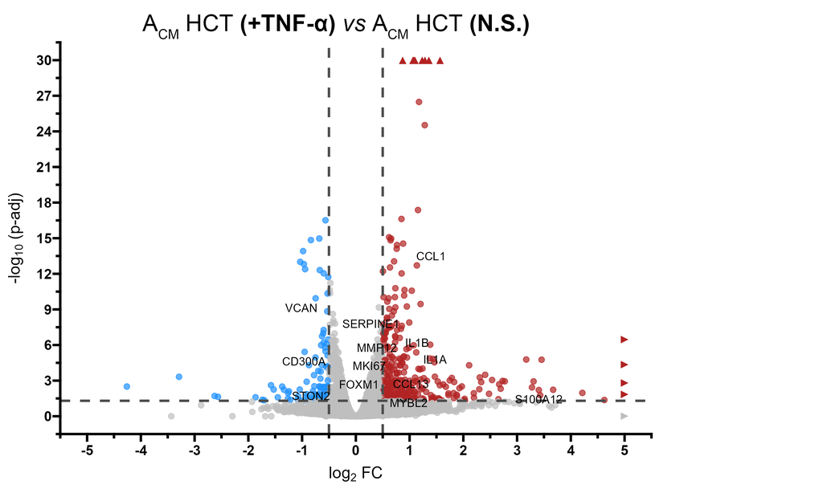

Example of Volcano Plot

```r
# Function to create tables, figures and rnk files

DEG_function <- function(fit, cont, gene_list){

  for (i in colnames(cont)){
    res <- assign(paste0('DEG_', i), glmLRT(fit, contrast = cont[,i]), pos = .GlobalEnv)
    res$table$SignedRank <- sign(res$table$logFC) * (-log10(res$table$PValue))
    res$table$Gene_Symbol <- gene_annot$SYMBOL[match(rownames(res$table), gene_annot$ENSEMBL)]
    res$table$Gene_Symbol[is.na(res$table$Gene_Symbol)] <- ''
    res <- topTags(res, n = Inf, sort.by = 'PValue')
    res$table$FDR[is.na(res$table$FDR)] = 1
    saveRDS(res, file = paste0('DEG_', i, '.rds'))
    res <- as.data.frame(res$table[order(res$table$FDR),]) %>% relocate(Gene_Symbol, .before = logFC)

# Create summarized table for sig and non-sig genes

    if (match(i, colnames(cont)) == 1){
      summary_deg <- data.frame(summary(decideTestsDGE(get(paste0('DEG_', i)), adjust.method = 'BH',
                                                      p.value = 0.05, lfc = 0.5)))

      column_df <- c(i)}

    else {
      new_summary <- data.frame(summary(decideTestsDGE(get(paste0('DEG_', i)), adjust.method = 'BH',
                                                       p.value = 0.05, lfc = 0.5)))

      summary_deg <- rbind(summary_deg, new_summary)
      column_df <- c(column_df, i)
    }

# Create DEG Table
    DEG_df <- res[,c(1:5,7)]
    write.table(DEG_df, file = paste0('DEG_edgeR_', i, '.csv'), sep = '\t', quote = F)

    # Volcano plot

    res <- res %>% mutate(
      color = case_when(logFC >= 0.5 & FDR < 0.05 ~ 'Upregulated',
                        logFC <= -0.5 & FDR < 0.05 ~ 'Downregulated',
                        TRUE ~ 'Unchanged'))

    res <- res %>% mutate(
      FC_coord = case_when(abs(logFC) > 5 ~ sign(logFC)*5,
                           TRUE ~ logFC))

    res <- res %>% mutate(
      FDR_coord = case_when(-log10(FDR) > 30 ~ 1e-30,
                            TRUE ~ FDR))

    res <- res %>% mutate(
      point = case_when(-log10(FDR) > 30 & abs(logFC) <= 5 ~ as.integer(-9650),
                        -log10(FDR) < 30 & logFC > 5 ~ as.integer(-9658),
                        -log10(FDR) < 30 & logFC < -5 ~ as.integer(-9668),
                        -log10(FDR) > 30 & logFC > 5 ~ as.integer(-9701),
                        -log10(FDR) > 30 & logFC < -5 ~ as.integer(-9700),
                        TRUE ~ as.integer(19)))

    volcano <- ggplot(res, aes(logFC, -log10(FDR), label = Gene_Symbol)) +
      geom_point(data = subset(res, point > 0), aes(color = color), alpha = 0.7, size = 2) +
      geom_hline(yintercept = -log10(0.05), linetype = 'dashed', color = 'grey30', linewidth = 1) +
      geom_vline(xintercept = c(-0.5,0.5), linetype = 'dashed', color = 'grey30', linewidth = 1) +
      ggtitle(substr(i, 1, nchar(i))) + coord_cartesian(xlim = c(-5,5), ylim = c(0,30)) +
      xlab(expression('log'[2]*' FC')) + ylab(expression('-log'[10]*' (p-adj)')) +
      scale_color_manual(values = c('dodgerblue', 'grey', 'firebrick'))+
      theme_prism() + theme(axis.title.x = element_text(family = 'sans', face = 'plain',
                                                        size = 14),
                            axis.title.y = element_text(family = 'sans', face = 'plain',
                                                        size = 14),
                            axis.text = element_text(family = 'sans', color = 'black', size = 12, face = 'bold'),
                            axis.line = element_line(linewidth = 1),
                            legend.text = element_text(family = 'sans', face = 'plain', size = 12),
                            legend.title = element_text(family = 'sans', face = 'bold', size = 14)) +
      scale_x_continuous(breaks = seq(-5,5,1), guide = guide_prism_minor()) +
      scale_y_continuous(breaks = seq(0,30,3), guide = guide_prism_minor()) +
      guides(colour = guide_legend(title = 'Expression', override.aes = list(size = 2))) +
      geom_point(data = subset(res, point < 0), aes (x = FC_coord, y = -log10(FDR_coord), color = color, shape = point),
                 size = 3) + scale_shape_identity() +
      geom_text_repel(data = subset(res, res$Gene_Symbol %in% gene_list & (abs(res$logFC) >= 0.5 & res$FDR < 0.05)), size = 3.5, family = 'sans', color = 'black',
                      force = 2, max.overlaps = Inf, xlim = c(-5,5), ylim = c(0,31), min.segment.length = unit(Inf, 'mm'))

    ggsave(paste0('DEG_', i, '.tiff'), plot = volcano, device = 'tiff',
           width = 250, height = 150, units = 'mm', compression = 'lzw')

  }

  summary_deg <- acast(summary_deg, Var1~Var2, value.var = 'Freq')
  colnames(summary_deg) <- column_df

  write.table(summary_deg, file = 'summarized_DEGs.csv', sep = '\t', quote = F)
}

# Calling DEG_function
# genes2plot represents a character list of gene symbols to be displayed in
# the volcano plot

DEG_function(new_fit, my_contrasts, genes2plot)
```

### Creating Venn-diagrams for overlapping up- and downregulated DEGs

```r
deg_hthn <- topTags(DEG_HCP_tnf_vs_HCP_ns, n = Inf)
deg_hthn <- deg_hthn$table
deg_hthn_up <- subset(deg_hthn, (deg_hthn$logFC >= 0.5 & deg_hthn$FDR < 0.05))
deg_hthn_up <- c(rownames(deg_hthn_up))
deg_hthn_down <- subset(deg_hthn, (deg_hthn$logFC <= -0.5 & deg_hthn$FDR < 0.05))
deg_hthn_down <- c(rownames(deg_hthn_down))

deg_snhn <- topTags(DEG_SCZ_ns_vs_HCP_ns, n = Inf)
deg_snhn <- deg_snhn$table
deg_snhn_up <- subset(deg_snhn, (deg_snhn$logFC >= 0.5 & deg_snhn$FDR < 0.05))
deg_snhn_up <- c(rownames(deg_snhn_up))
deg_snhn_down <- subset(deg_snhn, (deg_snhn$logFC <= -0.5 & deg_snhn$FDR < 0.05))
deg_snhn_down <- c(rownames(deg_snhn_down))

deg_sthn <- topTags(DEG_SCZ_tnf_vs_HCP_ns, n = Inf)
deg_sthn <- deg_sthn$table
deg_sthn_up <- subset(deg_sthn, (deg_sthn$logFC >= 0.5 & deg_sthn$FDR < 0.05))
deg_sthn_up <- c(rownames(deg_sthn_up))
deg_sthn_down <- subset(deg_sthn, (deg_sthn$logFC <= -0.5 & deg_sthn$FDR < 0.05))
deg_sthn_down <- c(rownames(deg_sthn_down))

venn_diagram_up <- venn.diagram(x = list(deg_hthn_up, deg_snhn_up, deg_sthn_up),
                                filename = 'Venn Diagram Upregulated DEGs.tiff',
                                main = 'Shared Upregulated DEGs',
                                main.fontfamily = 'sans', sub.fontfamily = 'sans',
                                category.names = c('vs_HCP_tnf', 'vs_SCZ_ns', 'vs_SCZ_tnf'),
                                output = F, lwd = 1, col = 'black', cat.cex = 0.2, cex = 1,
                                fill = viridis(3, alpha = 0.3, option = 'viridis'), fontfamily = 'sans',
                                cat.fontfamily = "sans", euler.d = F, scaled = F,
                                disable.logging = T, height = 1500, width = 1500)

venn_diagram_down <- venn.diagram(x = list(deg_hthn_down, deg_snhn_down, deg_sthn_down),
                                filename = 'Venn Diagram Downregulated DEGs.tiff',
                                main = 'Shared Downregulated DEGs',
                                main.fontfamily = 'sans', sub.fontfamily = 'sans',
                                category.names = c('vs_HCP_tnf', 'vs_SCZ_ns', 'vs_SCZ_tnf'),
                                output = F, lwd = 1, col = 'black', cat.cex = 0.2, cex = 1,
                                fill = viridis(3, alpha = 0.3, option = 'viridis'), fontfamily = 'sans',
                                cat.fontfamily = "sans", euler.d = F, scaled = F,
                                disable.logging = T, height = 1500, width = 1500)
```

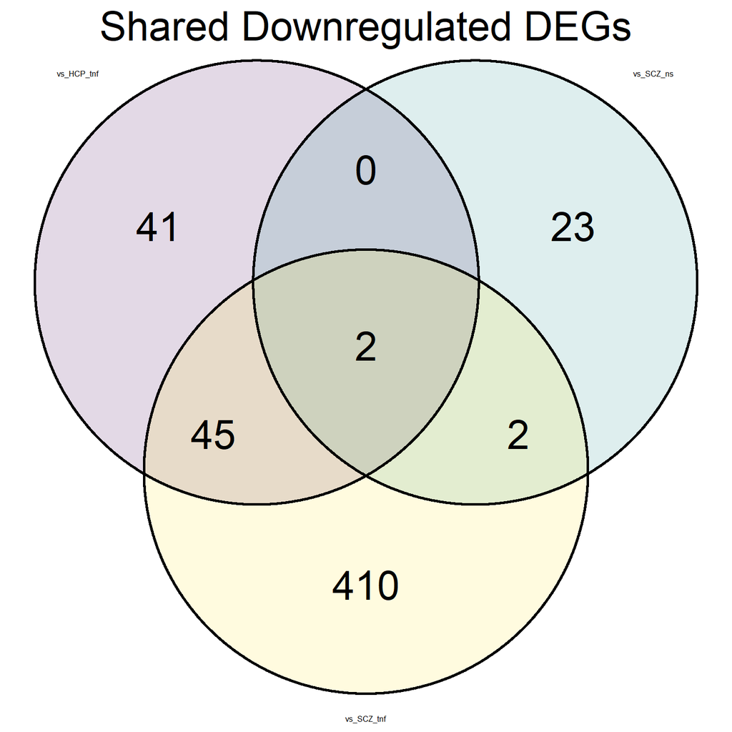

Example of Venn Diagram

### Principal component analysis

PCA analysis was carried out using RUV-seq normalized gene count matrix.

```r
p <- pca(as.matrix(log(normCounts(ruvr_model))), metadata = pData(new_set), removeVar = 0.1, scale = TRUE)

tiff('Multiple_PCA_plot_all_groups.tiff', width = 225, height = 100, unit = 'mm',
     res = 600, compression = 'lzw')

pairsplot(p, components = getComponents(p, c(1,2,3)), colby = colnames(p$metadata),
          colkey = c('hcp_ns'='#69b9f5', 'hcp_tnf'='#0b5394', 'scz_ns'='#fd9d9d', 'scz_tnf'='#e50000'),
          pointSize = 2, plotaxes = TRUE, hline = 0, vline = 0, legendPosition = 'top',
          legendLabSize = 8, legendIconSize = 4, axisLabSize = 10, shapekey = 21,
          ncol = 3, nrow = 1, triangle = FALSE, title = 'PCAs of iMGs incubated with ACMs',
          titleLabSize = 12, ylabhjust = 1.3, xlabvjust = 1.5)

dev.off()
```

### Other files generated for further analysis

As part of this code, we also generated other files to be used in further analysis, such as in the GSEA and also for Master Regulon Analysis (MRA)

```r
# Mean-centered logCPM values to generate GSEA heatmaps

logCPM <- t(scale(t(logCPM), scale = F))

o <- order(DEG_tnf_vs_ns$table$PValue)

write.table(o, file = 'ordered_elements_from_DEG_all_edgeR.csv', quote = F, sep = '\t')

# Create DEG files for MRA

deg_hthn <- topTags(DEG_HCP_tnf_vs_HCP_ns, n = Inf)
deg_hthn <- deg_hthn$table
deg_hthn <- subset(deg_hthn, rownames(deg_hthn) %in% gene_annot$ENSEMBL)
deg_hthn$FDR[is.na(deg_hthn$FDR)] <- 1

deg_snhn <- topTags(DEG_SCZ_ns_vs_HCP_ns, n = Inf)
deg_snhn <- deg_snhn$table
deg_snhn <- subset(deg_snhn, rownames(deg_snhn) %in% gene_annot$ENSEMBL)
deg_snhn$FDR[is.na(deg_snhn$FDR)] <- 1

deg_sthn <- topTags(DEG_SCZ_tnf_vs_HCP_ns, n = Inf)
deg_sthn <- deg_sthn$table
deg_sthn <- subset(deg_sthn, rownames(deg_sthn) %in% gene_annot$ENSEMBL)
deg_sthn$FDR[is.na(deg_sthn$FDR)] <- 1

#Create named numeric with logFC

num_deg_hthn <- setNames(deg_hthn$logFC, rownames(deg_hthn))
num_deg_snhn <- setNames(deg_snhn$logFC, rownames(deg_snhn))
num_deg_sthn <- setNames(deg_sthn$logFC, rownames(deg_sthn))

num_degs <- list('num_deg_hthn' = num_deg_hthn, 'num_deg_snhn' = num_deg_snhn,
                 'num_deg_sthn' = num_deg_sthn)

saveRDS(num_degs, file = 'numeric_named_DEGs.rds')

# Filter for FDR < 0.05 & abs(logFC) >= 0.5

deg_hthn <- deg_hthn[deg_hthn$FDR < 0.05,]
deg_hthn <- deg_hthn[abs(deg_hthn$logFC) >= 0.5,]

deg_snhn <- deg_snhn[deg_snhn$FDR < 0.05,]
deg_snhn <- deg_snhn[abs(deg_snhn$logFC) >= 0.5,]

deg_sthn <- deg_sthn[deg_sthn$FDR < 0.05,]
deg_sthn <- deg_sthn[abs(deg_sthn$logFC) >= 0.5,]

# Get hits (DEGs) list

hits_deg_hthn <- rownames(deg_hthn)
hits_deg_snhn <- rownames(deg_snhn)
hits_deg_sthn <- rownames(deg_sthn)

hits <- list('hits_deg_hthn' = hits_deg_hthn, 'hits_deg_snhn' = hits_deg_snhn,
             'hits_deg_sthn' = hits_deg_sthn)

saveRDS(hits, file = 'hits_DEGs.rds')
```

We also used the following code to calculate the transcriptional age of our samples.

```r
# Transcriptional age calculations

chrono_age <- data.frame(samples = colnames(norm_counts_data), chrono_age = 45)

age_calc <- predict_age(norm_counts_data, tissue = 'brain', exprtype = 'counts', idtype = 'ENSEMBL',
                        signature = 'GTExAge', stype = 'all', chronage = chrono_age)

age_calc$var1 <- 'Sample'
age_calc$var2 <- 'Mean'

age_calc$sample_gap <- age_calc$RNAAge - mean(age_calc$RNAAge[1:3])

age_calc$mean_gap <- 0
age_calc$mean_gap[1:3] <- mean(age_calc$RNAAge[1:3]) - mean(age_calc$RNAAge[1:3])
age_calc$mean_gap[4:6] <- mean(age_calc$RNAAge[4:6]) - mean(age_calc$RNAAge[1:3])
age_calc$mean_gap[7:9] <- mean(age_calc$RNAAge[7:9]) - mean(age_calc$RNAAge[1:3])
age_calc$mean_gap[10:12] <- mean(age_calc$RNAAge[10:12]) - mean(age_calc$RNAAge[1:3])

age_calc$groups <- rep(c('hct_ns', 'hct_tnf', 'scz_ns', 'scz_tnf'), each = 3)
age_calc$diagnostic <- rep(c('hct', 'scz'), each = 6)
age_calc$stimulation <- rep(c('ns', 'tnf'), each = 3, times = 2)

plot_age_calc <- ggplot(age_calc, aes(fill = groups, color = groups)) +
  geom_point(aes(x = mean_gap, y = var2), size = 5, shape = 23, color = 'black', stroke = 1) +
  geom_point(aes(x = sample_gap, y = var1), size = 4, shape = 21) +
  scale_fill_manual(values = c('hct_ns'='#69b9f5', 'hct_tnf'='#0b5394', 'scz_ns'='#fd9d9d', 'scz_tnf'='#e50000')) +
  scale_color_manual(values = c('hct_ns'='#69b9f5', 'hct_tnf'='#0b5394', 'scz_ns'='#fd9d9d', 'scz_tnf'='#e50000')) +
  scale_x_continuous(breaks = seq(-2,9,1), guide = guide_prism_minor()) +
  xlab('Age gap (relative to ACM HCT (N.S.))') + ylab('') +
  theme_prism() + theme(axis.title.x = element_text(family = 'sans', face = 'plain',
                                                    size = 12),
                        axis.text = element_text(family = 'sans', color = 'black', size = 11, face = 'bold'),
                        axis.line.x = element_line(linewidth = 1),
                        axis.line.y = element_blank(), axis.ticks.y = element_blank(),
                        legend.text = element_text(family = 'sans', face = 'plain', size = 11),
                        legend.title = element_blank(), legend.key.size = unit(4, 'mm'),
                        panel.grid.major.y = element_line(color = 'grey95', linewidth = 10))

anova_age <- aov(sample_gap ~ diagnostic*stimulation, data = age_calc)
emmean_age <- emmeans(anova_age, ~ diagnostic*stimulation, adjust = 'sidak')
pwcomp_age <- cld(emmean_age, adjust = 'sidak', Letters = letters)

ggsave('RNAAgeCalc.pdf', plot = plot_age_calc, height = 1.6)
```